Explore Two Variables

========================================================

Learn techniques for exploring the relationship between any two variables in a data set, including scatter plots, line plots, and correlations.

- Investigate two quantitative variables;
- Visualize and Quantify that relationship;
- Data Aggregation;
- Conditional Means;
- Scatterplots;

`setwd("e:/_deep_learning/_data_analysis/6. EDA/lesson5")`

### Scatterplots and Perceived Audience Size

Notes:

How people guesses about their audience size matched up with their actual audience size using scatterplots of perceived audience versus actual audience per one post.

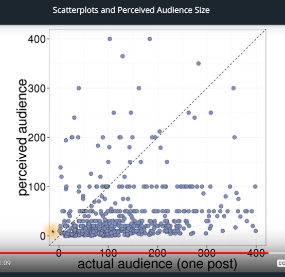

Scatterplot

- If their guess is accurate, their guess would fall along the perfect accuracy line;
- There are these horizontal stripes because people are guessing these regular numbers at 50, 100, 200;
- It’s a big cluster at the bottom;
- People are guessing very small numbers: 20, 50 when in reality their audience size is 100 or 200;

```r
library(ggplot2)
pf <- read.csv('../lesson3/pseudo_facebook.tsv', sep = '\t')
head(pf)
```

```
##    userid age dob_day dob_year dob_month gender tenure friend_count
## 1 2094382  14      19     1999        11   male    266            0
## 2 1192601  14       2     1999        11 female      6            0
## 3 2083884  14      16     1999        11   male     13            0
## 4 1203168  14      25     1999        12 female     93            0
## 5 1733186  14       4     1999        12   male     82            0
## 6 1524765  14       1     1999        12   male     15            0
##   friendships_initiated likes likes_received mobile_likes
## 1                     0     0              0            0
## 2                     0     0              0            0
## 3                     0     0              0            0
## 4                     0     0              0            0
## 5                     0     0              0            0
## 6                     0     0              0            0
##   mobile_likes_received www_likes www_likes_received
## 1                     0         0                  0
## 2                     0         0                  0
## 3                     0         0                  0
## 4                     0         0                  0
## 5                     0         0                  0
## 6                     0         0                  0
```

### Scatterplots

Notes:

Let’s look at two continuous variables at the same time with a scatterplot.

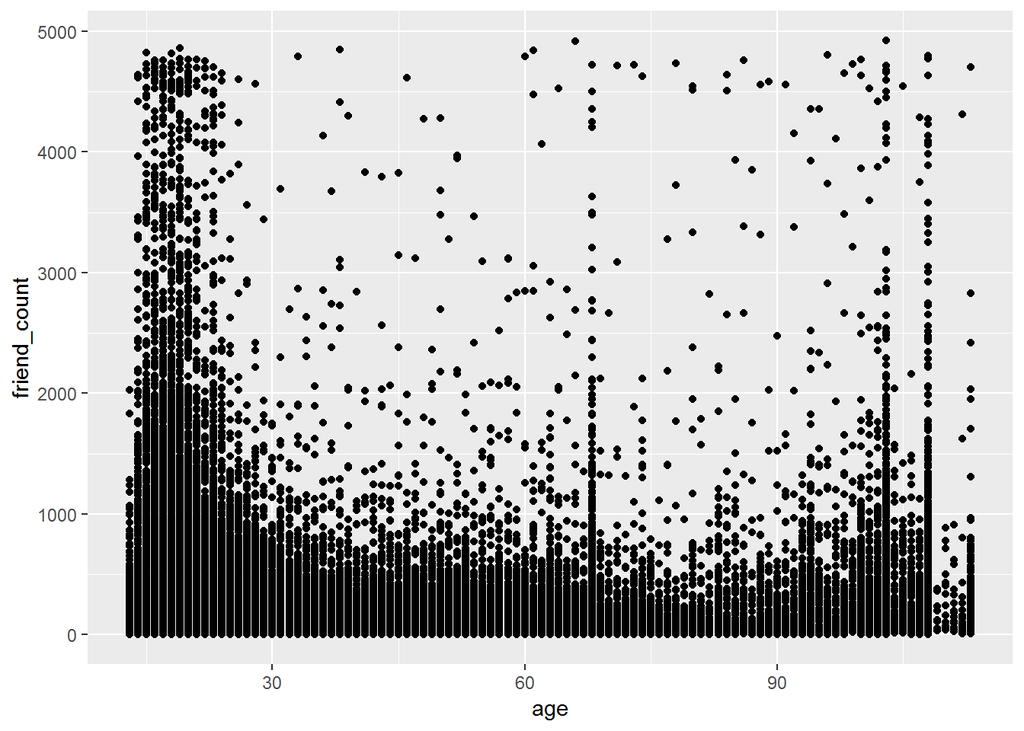

```r
qplot(x = age, y = friend_count, data = pf)
```

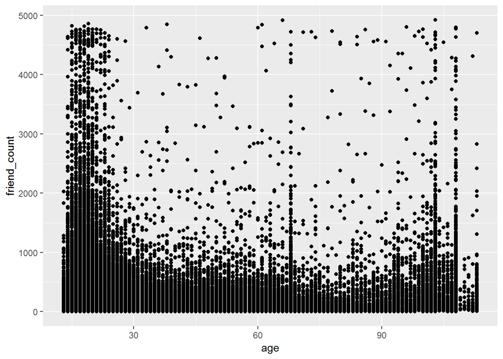

```r
# this plot is equivalent to the one from above
# not using the x and y parameters explicitly
qplot(age, friend_count, data = pf)
```

There isn’t a user interface (UI) feature on Facebook’s website that causes people to pick the particular age of 69 or the older ages. In general, it is a good idea to think about what caused certain oddities or values in data sets. This can help explain dirty data.

#### What are some things that you notice right away?

Response:

- Younger users have a lot of friends, thousands more friends than most users over the age of 30.
- There are some vertical bars where people lied about their age, like 69 and 100. These are likely to be teenagers or fake accounts.
- The data is kind of messy.
- We can see that there are some outliers, people with ages higher that 100 years old.
- Users with age between 13-30 have more friend counts.

### ggplot Syntax

Notes:

1. [ggplot2 geoms](https://ggplot2.tidyverse.org/reference/)
2. [ggplot2 tutorial](http://bbs.ceb-institute.org/wp-content/uploads/2011/09/handout_ggplot2.pdf) by Ramon Saccilotto

The equivalent `ggplot` syntax for the scatterplot:

- Will let us specify more complicated plots;
- We have to say what type of geom or chart type that we want;
- For scatterplot is `geom_point`;
- It uses the `aes` aesthetic wrapper;
- Use ranges for `age`: the minimum is 13 and the maximum is 113;
- Use the `xlim` layer to set the ranges for the x axis’

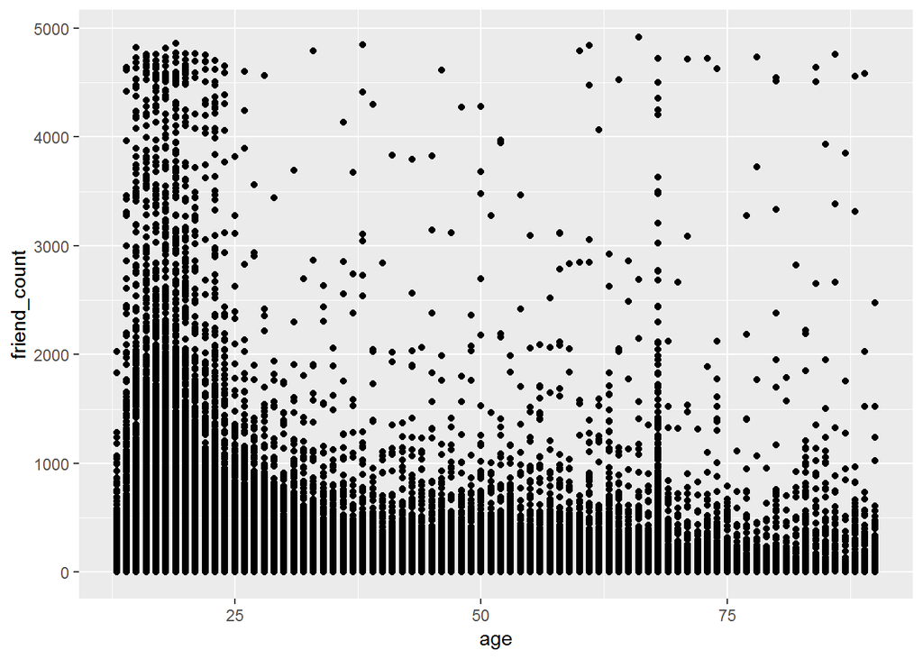

```r
ggplot(aes(x = age, y = friend_count), data = pf) +
  geom_point() +
  xlim(13, 90)
```

```r
summary(pf$age)
```

```
##    Min. 1st Qu.  Median    Mean 3rd Qu.    Max.
##   13.00   20.00   28.00   37.28   50.00  113.00
```

### Overplotting

Notes:

- Some of the points are spread out to one another while others are stacked right on top of each other.
- Those stacked on top of each other are overplotted.
- It makes it difficult to see how many points are in each region.
- We set the transparency of the points using the alpha parameter and geom point.
- `alpha = 1/20` it means it’s going to take 20 points to be the equivalent of the black dots.
- Now we can see that the bulk of our data lies below the 1000 treshold for friend count.
- Let’s add a `jitter`. We can swap `geom_point` with the `geom_jitter`, `age` is continuous data, using `jitter` we can add noise to each age to get a clearer picture. We get a more dispersed distribution.

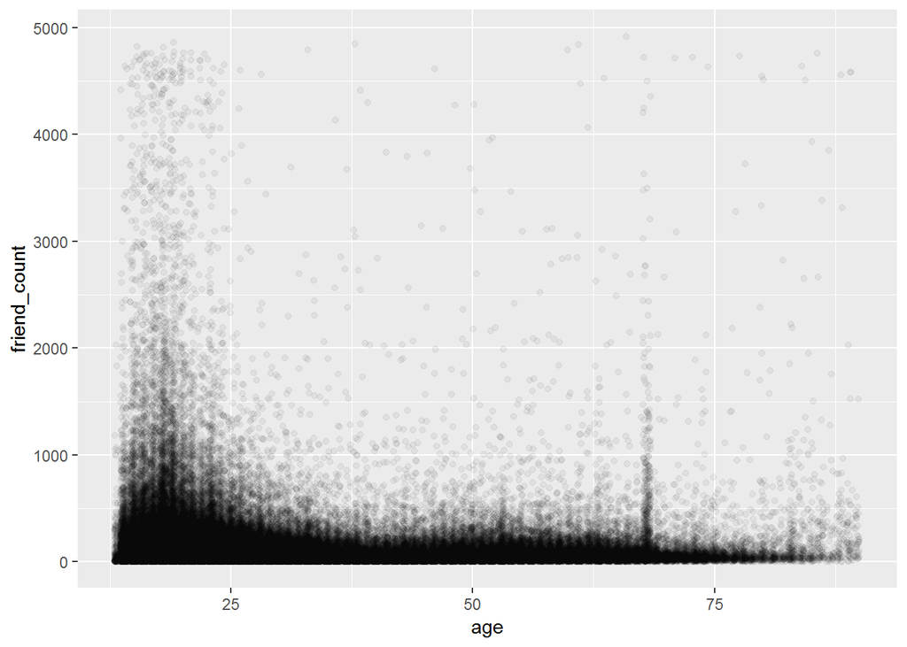

```r
ggplot(aes(x = age, y = friend_count), data = pf) +
  geom_jitter(alpha = 1/20) +
  xlim(13, 90)
```

#### What do you notice in the plot?

Response:

The bulk of younger users, under 25, have friend counts of less than 1000. We can see around age 69 a peak friend count threshold of 1000 compared to the 25 years old users group. Typically, users older than 25 years have friend counts under 500. For users older than 70 the threshold is lower at around 250 and further decreasing after 75 years.

### Coord_trans()

Notes: Look up the documentation for `coord_trans()` by running this line of code `?coord_trans` or visit http://docs.ggplot2.org/current/coord_trans.html.

- Use a transformation on the y axis, change the `friend_count` to get a better visualization.
- Use the square root function.
- Look up the documentation for `coord_trans()` and add a layer to the plot that transforms `friend_count` using the square root function.
- Create your plot!

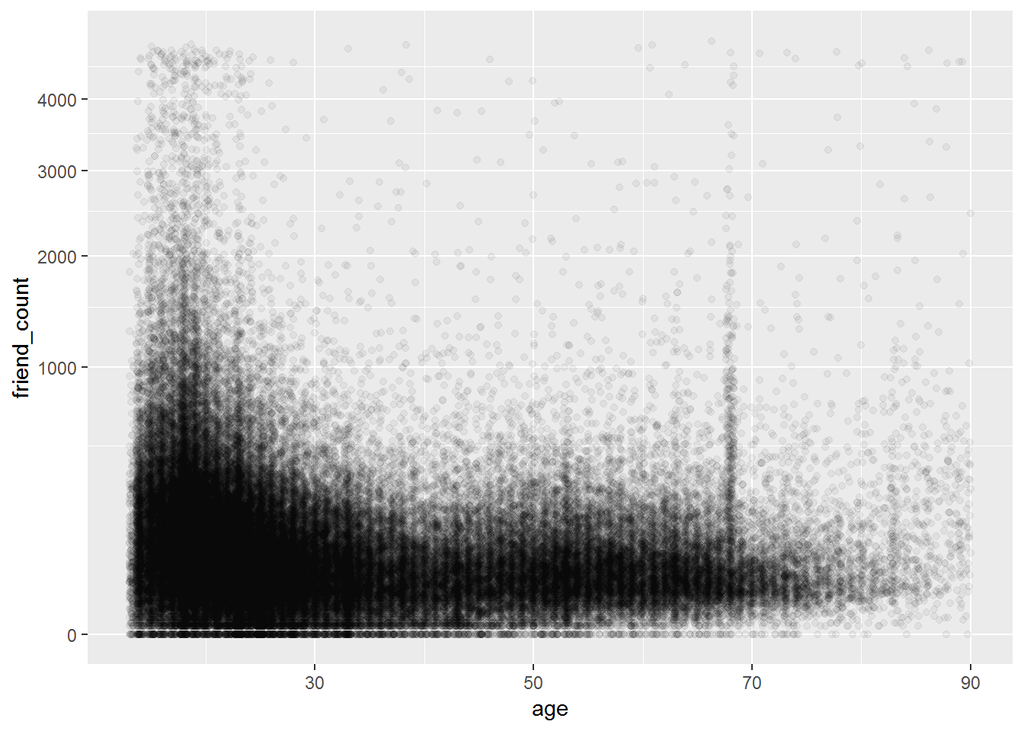

```r
#?coord_trans
ggplot(aes(x = age, y = friend_count), data = pf) +
  geom_point(alpha = 1/20, position = position_jitter(h = 0)) +
  xlim(13, 90) +
  coord_trans(y = "sqrt")
```

### Alpha and Jitter

Notes:

- Explore the relationship between friends initiated and age.
- Use a `coord_trans` layer to better see the bulk of our data by taking the square root of our y-axis.

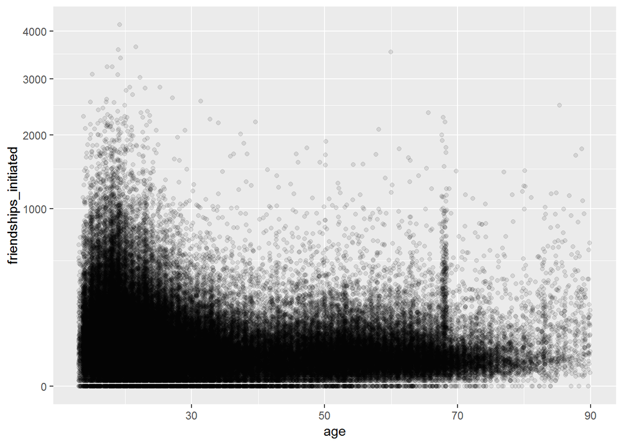

```r
ggplot(aes(x = age, y = friendships_initiated), data = pf) +
  geom_point(alpha = 1/10, position = position_jitter(h = 0)) +
  xlim(13, 90) +
  coord_trans(y = "sqrt")
```

### Overplotting and Domain Knowledge

Notes:

We use Alpha and Jitter to reduce overplotting.

Some other transformations:

- As a percentage, you would expect the x-axis variable to be bounded with the y-axis variable;
- The percentage of friends who actually saw the content in the last month.

### Conditional Means

Notes:

Learn more about the `dplyr` package.

1. Introduction to [dplyr](https://blog.rstudio.com/2014/01/17/introducing-dplyr/) (knitted html file)
2. [Introduction of dplyr](https://www.r-bloggers.com/hadley-wickham-presents-dplyr-at-user-2014/)
3. [dplyr Tutorial Part 1](https://www.r-bloggers.com/hadley-wickhams-dplyr-tutorial-at-user-2014-part-1/)
4. [dplyr Tutorial Part 2](https://www.r-bloggers.com/hadley-wickhams-dplyr-tutorial-at-user-2014-part-2/)
5. There are other ways to work with data and create new data frames without using the dplyr package. Learn about the R functions `lapply`, `tapply`, and `split` in a [blog post](https://rollingyours.wordpress.com/2014/10/20/the-lapply-command-101/).
6. For more on `geom_line()`, you can check the documentation [here](https://ggplot2.tidyverse.org/reference/geom_path.html).

Scatterplot of `friend_count` and `age`:

- We are visualizing every point in the data set and it is not possible to judge important quantities from such a display.Sometimes you want to understand how the mean or median of a variable varies with another variable. It is important to summarize the relationship between two variable in other ways rather than just plotting every single point.
- We can ask, how does the average friend count vary over age?
- Create a table that for each age gives us the mean and median friend count.
- Use `dplyr`: it let’s us split up a dataframe and apply a function to some parts of the data.
- Functions: `filter()`, `group_by()`, `mutate()`, `arrange()`
- `n()` can be used only for summarize and it reports how many people are in each group.

```r
#install.packages("dplyr")
library(dplyr)
# group dataframe by age
age_groups <- group_by(pf, age)
# summarize the age_group and create new var of mean and median friend_count
# and the number of people in each group
pf.fc_by_age <- summarise(age_groups,
          friend_count_mean = mean(friend_count),
          friend_count_median = median(friend_count),
          n = n())
# sort it by age
pf.fc_by_age <- arrange(pf.fc_by_age, age)
head(pf.fc_by_age)
```

```
## # A tibble: 6 x 4
##     age friend_count_mean friend_count_median     n
##   <int>             <dbl>               <dbl> <int>
## 1    13              165.                 74    484
## 2    14              251.                132   1925
## 3    15              348.                161   2618
## 4    16              352.                172.  3086
## 5    17              350.                156   3283
## 6    18              331.                162   5196
```

```r
# chain functions onto out daya set
pf.fc_by_age <- pf %>%
  group_by(age) %>%
  summarise(friend_count_mean = mean(friend_count),
          friend_count_median = median(friend_count),
          n = n()) %>%
  arrange(age)

head(pf.fc_by_age, 20)
```

```
## # A tibble: 20 x 4
##      age friend_count_mean friend_count_median     n
##    <int>             <dbl>               <dbl> <int>
##  1    13              165.                74     484
##  2    14              251.               132    1925
##  3    15              348.               161    2618
##  4    16              352.               172.   3086
##  5    17              350.               156    3283
##  6    18              331.               162    5196
##  7    19              334.               157    4391
##  8    20              283.               135    3769
##  9    21              236.               121    3671
## 10    22              211.               106    3032
## 11    23              203.                93    4404
## 12    24              186.                92    2827
## 13    25              131.                62    3641
## 14    26              144.                75    2815
## 15    27              134.                72    2240
## 16    28              126.                66    2364
## 17    29              121.                66    1936
## 18    30              115.                67.5  1716
## 19    31              118.                63    1694
## 20    32              114.                63    1443
```

Show the observations with a visualization. Let’s plot this table of averages: Average `friend_count` versus `age`.

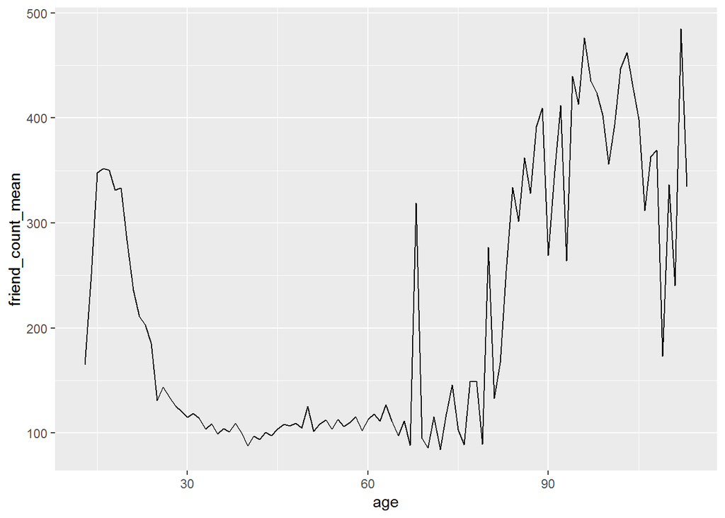

```r
ggplot(aes(x = age, y = friend_count_mean), data = pf.fc_by_age) +
  geom_line()
```

Displaying summaries.

This plot immediately makes clear the patterns we menttioned before, as well as the oddnes as age 69. We see that with the older ages, our estimates are highly variable for friend count mean. For our young users they still have high friend counts. For the users with ages between 30 and 60 the mean count is hovering just over 100.

### Overlaying Summaries with Raw Data

Notes:

- Combining plots of raw data with displaying summaries by adding a `geom_line` to our original scatterplot.
- `fun.y` parameter takes in any type of function so that we can apply it to the y values.
- We can display multiple summaries at the same time.
- We can’t see how dispersed the data is around the mean;
- We can see that most users, even young ones don’t have more than 2000 friends.
- We can better understand this distribution of friend counts by also plotting quantiles of the data. Let’s use the 10% (set the probability to 10% or 0.1), 50% or median and 90% quantile summary line;
- 90% of users have friend count below the 90% quantile summary line.

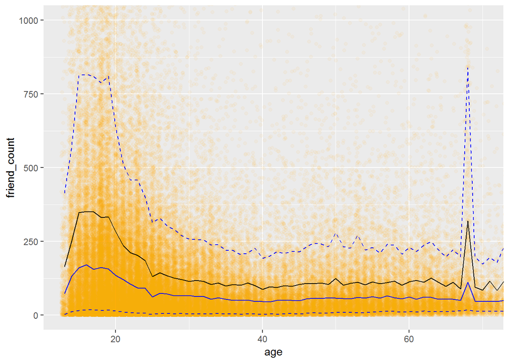

```r
ggplot(aes(x = age, y = friend_count), data = pf) +
  coord_cartesian(xlim = c(13, 70), ylim = c(0, 1000)) +
  geom_point(alpha = 1/20,
             position = position_jitter(h = 0),
             color = 'orange') +
  geom_line(stat = 'summary', fun.y = mean) +
  geom_line(stat = 'summary', fun.y = quantile,
            fun.args = list(probs = .1),
            linetype = 2, color = 'blue') +
  geom_line(stat = 'summary', fun.y = quantile,
            fun.args = list(probs = .9),
            linetype = 2, color = 'blue') +
  geom_line(stat = 'summary', fun.y = quantile,
            fun.args = list(probs = .5),
            linetype = 1, color = 'blue')
```

#### What are some of your observations of the plot?

Response:

### Moira: Histogram Summary and Scatterplot

Notes:

Pair raw data with summary data:

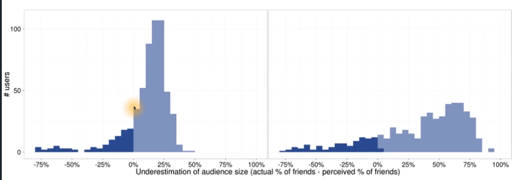

How much people underestimate their audience size?

### Correlation

Notes:

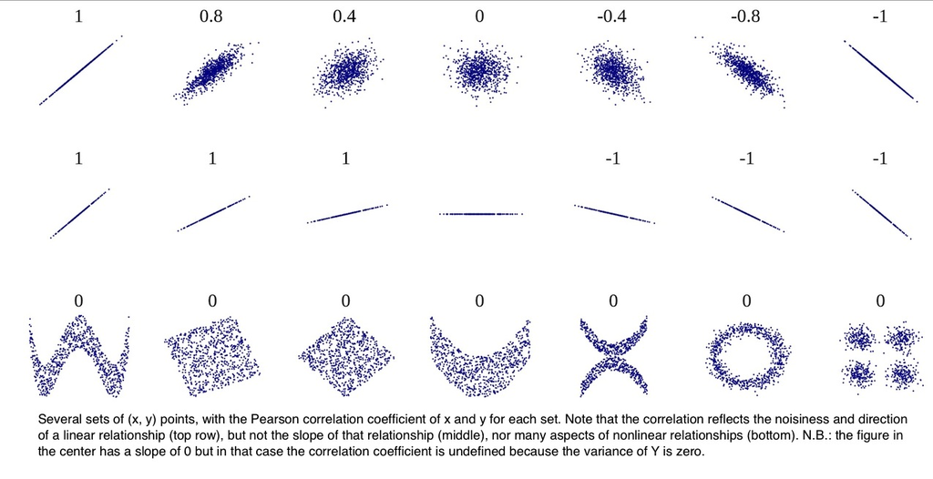

A Visual Guide to Correlation

- [Correlation Coefficient](http://www.r-tutor.com/elementary-statistics/numerical-measures/correlation-coefficient)
- [Intro to Inferential Statistics- Correlation](https://classroom.udacity.com/courses/ud201/lessons/1345848540/concepts/1715827370923)

Correlation coefficients are often denoted with the greek letter (rho), in addition to the letter `r`.

The default method for computing the correlation coefficient is `Pearson`, and this is true for most statistical software. You do not need to pass the method parameter when calculating the `Pearson Product Moment Correlation`.

We could try to summarize the strength of this linear relationship in a single number with the correlation coefficient.

```r
cor.test(pf$age, pf$friend_count, method = 'pearson')
```

```
##
##  Pearson's product-moment correlation
##
## data:  pf$age and pf$friend_count
## t = -8.6268, df = 99001, p-value < 2.2e-16
## alternative hypothesis: true correlation is not equal to 0
## 95 percent confidence interval:
##  -0.03363072 -0.02118189
## sample estimates:
##         cor
## -0.02740737
```

```r
with(pf, cor.test(age, friend_count))
```

```
##
##  Pearson's product-moment correlation
##
## data:  age and friend_count
## t = -8.6268, df = 99001, p-value < 2.2e-16
## alternative hypothesis: true correlation is not equal to 0
## 95 percent confidence interval:
##  -0.03363072 -0.02118189
## sample estimates:
##         cor
## -0.02740737
```

Look up the documentation for the `cor.test` function.

What’s the correlation between age and friend count? Round to three decimal places. Response: -0.027

This indicates that there’s no meaningful relationship between the two variables.

### Correlation on Subsets

Notes:

[What are monotonic functions?](https://en.wikipedia.org/wiki/Monotonic_function)

The relationship between `age` and `friend_count` is not linear. It isn’t monotonic, either increasing or decreasing. We may don’t want to include the older ages in out correlation number since they are likely to be incorrect. Let’s use users `age` less than 70.

```r
with(subset(pf, age <= 70), cor.test(age, friend_count),
     method = 'pearson')
```

```
##
##  Pearson's product-moment correlation
##
## data:  age and friend_count
## t = -52.592, df = 91029, p-value < 2.2e-16
## alternative hypothesis: true correlation is not equal to 0
## 95 percent confidence interval:
##  -0.1780220 -0.1654129
## sample estimates:
##        cor
## -0.1717245
```

A negative relationship between age and friend count. As age increases, we can see friend count decreases.

### Correlation Methods

Notes:

[Correlation Methods: Pearson’s r, Spearman’s rho, and Kendall’s tau](https://www.statisticssolutions.com/correlation-pearson-kendall-spearman/) Other types of relationships: - rank correlation measures like Spearman

```r
with(subset(pf, age <= 70), cor.test(age, friend_count),
     method = 'spearman')
```

```
##
##  Pearson's product-moment correlation
##
## data:  age and friend_count
## t = -52.592, df = 91029, p-value < 2.2e-16
## alternative hypothesis: true correlation is not equal to 0
## 95 percent confidence interval:
##  -0.1780220 -0.1654129
## sample estimates:
##        cor
## -0.1717245
```

## Create Scatterplots

Notes:

Number of likes users received from friends on the desktop version on the site `www_likes_received`. We’ll compare this variable to the total number of likes users received which is the likes received `likes_received`.

```r
summary(pf$likes_received)
```

```
##     Min.  1st Qu.   Median     Mean  3rd Qu.     Max.
##      0.0      1.0      8.0    142.7     59.0 261197.0
```

```r
summary(pf$www_likes_received)
```

```
##      Min.   1st Qu.    Median      Mean   3rd Qu.      Max.
##      0.00      0.00      2.00     58.57     20.00 129953.00
```

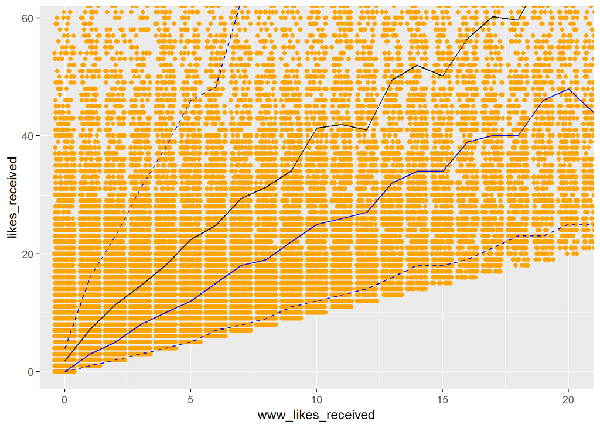

```r
ggplot(aes(x = www_likes_received, y = likes_received), data = pf) +
  coord_cartesian(xlim = c(0, 20), ylim = c(0, 59)) +
  geom_point(alpha = 1,
             position = position_jitter(h = 0),
             color = 'orange') +
  geom_line(stat = 'summary', fun.y = mean) +
  geom_line(stat = 'summary', fun.y = quantile,
            fun.args = list(probs = .1),
            linetype = 2, color = 'blue') +
  geom_line(stat = 'summary', fun.y = quantile,
            fun.args = list(probs = .9),
            linetype = 2, color = 'blue') +
  geom_line(stat = 'summary', fun.y = quantile,
            fun.args = list(probs = .5),
            linetype = 1, color = 'blue')
```

### Strong Correlations

Notes:

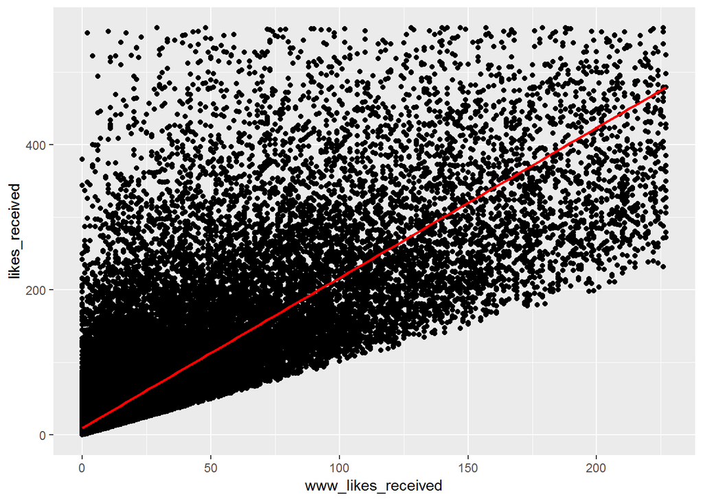

```r
ggplot(aes(x = www_likes_received, y = likes_received), data = pf) +
  geom_point() +
  xlim(0, quantile(pf$www_likes_received, 0.95)) +
  ylim(0, quantile(pf$likes_received, 0.95)) +
  geom_smooth(method = 'lm', color = 'red')
```

- There are some outliers in our data.
- Look at the 95th percentile using the Quantile to determine x and y axis.
- Add the slope of the line of the best fit is the correlation by adding a smother and setting the method to a linear model, `lm`.

The correlation coefficient is invariant under a linear transformation of either X or Y, and the slope of the regression line when both X and Y have been transformed to z-scores is the correlation coefficient.

It’s important to note that we may not always be interested in the bulk of the data. Sometimes, the outliers ARE of interest, and it’s important that we understand their values and why they appear in the data set.

What’s the correlation betwen the two variables? Include the top 5% of values for the variable in the calculation and round to 3 decimal places.

```r
cor.test(pf$www_likes_received, pf$likes_received)
```

```
##
##  Pearson's product-moment correlation
##
## data:  pf$www_likes_received and pf$likes_received
## t = 937.1, df = 99001, p-value < 2.2e-16
## alternative hypothesis: true correlation is not equal to 0
## 95 percent confidence interval:
##  0.9473553 0.9486176
## sample estimates:
##       cor
## 0.9479902
```

Response: 0.9479902

This is a strong positive correlation. One of the variable was a superset of the other. When doing regression and creating a model. One of the assumptions of regression is these variables are independent of each other. It is hard to tell which one is driving the phenomenon. So, it is good practice to calculate the correlation to determine which one ot to use when doing regression.

### Moira on Correlation

Notes: Strong correlations might not always be a good think. If variables measure the same thing, they tend to be correlated.

### More Caution with Correlation

Notes:

Plotting your data is the best way to help you understand it.

```r
#install.packages('alr3')
library(alr3)
data(Mitchell)
#?Mitchell
names(Mitchell)
```

```
## [1] "Month" "Temp"
```

Create your plot!

We will see how correlation can be somewhat deceptive. Let’s take a look at this scatterplot of `temperature` versus `month`.

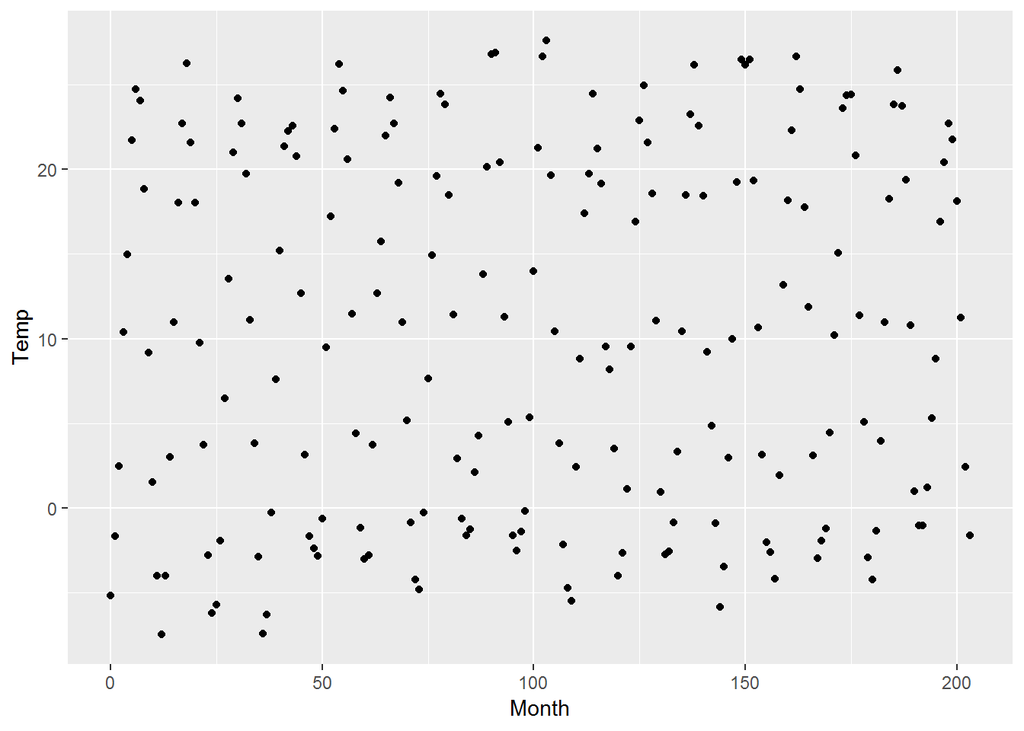

```r
ggplot(aes(x=Month, y = Temp), data = Mitchell) +
  geom_point()
```

### Noisy Scatterplots

1. Take a guess for the correlation coefficient for the scatterplot. 0
2. What is the actual correlation of the two variables? (Round to the thousandths place)

```r
cor.test(Mitchell$Month, Mitchell$Temp)
```

```
##
##  Pearson's product-moment correlation
##
## data:  Mitchell$Month and Mitchell$Temp
## t = 0.81816, df = 202, p-value = 0.4142
## alternative hypothesis: true correlation is not equal to 0
## 95 percent confidence interval:
##  -0.08053637  0.19331562
## sample estimates:
##        cor
## 0.05747063
```

### Making Sense of Data

Notes: The Months variable is discreet. Let’s add this detail to our plot.

```r
range(Mitchell$Month)
```

```
## [1]   0 203
```

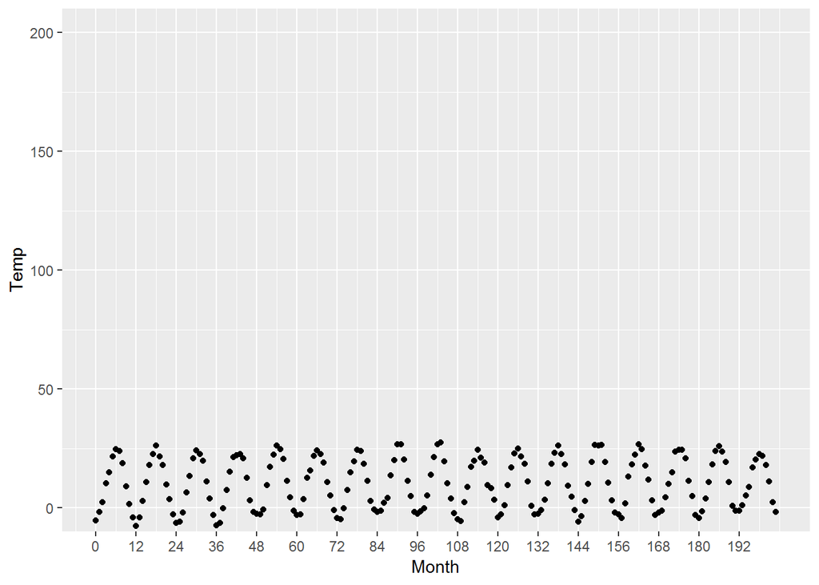

```r
ggplot(aes(x=Month, y = Temp), data = Mitchell) +
  geom_point() +
  scale_x_continuous(breaks = seq(0, 203, 12)) +
  coord_cartesian(ylim = c(0, 200))
```

```r
Mitchell$Month %% 12
```

```
##   [1]  0  1  2  3  4  5  6  7  8  9 10 11  0  1  2  3  4  5  6  7  8  9 10
##  [24] 11  0  1  2  3  4  5  6  7  8  9 10 11  0  1  2  3  4  5  6  7  8  9
##  [47] 10 11  0  1  2  3  4  5  6  7  8  9 10 11  0  1  2  3  4  5  6  7  8
##  [70]  9 10 11  0  1  2  3  4  5  6  7  8  9 10 11  0  1  2  3  4  5  6  7
##  [93]  8  9 10 11  0  1  2  3  4  5  6  7  8  9 10 11  0  1  2  3  4  5  6
## [116]  7  8  9 10 11  0  1  2  3  4  5  6  7  8  9 10 11  0  1  2  3  4  5
## [139]  6  7  8  9 10 11  0  1  2  3  4  5  6  7  8  9 10 11  0  1  2  3  4
## [162]  5  6  7  8  9 10 11  0  1  2  3  4  5  6  7  8  9 10 11  0  1  2  3
## [185]  4  5  6  7  8  9 10 11  0  1  2  3  4  5  6  7  8  9 10 11
```

### A New Perspective

Response: We see fluctuation in the temperature every 12 months.

Notes:

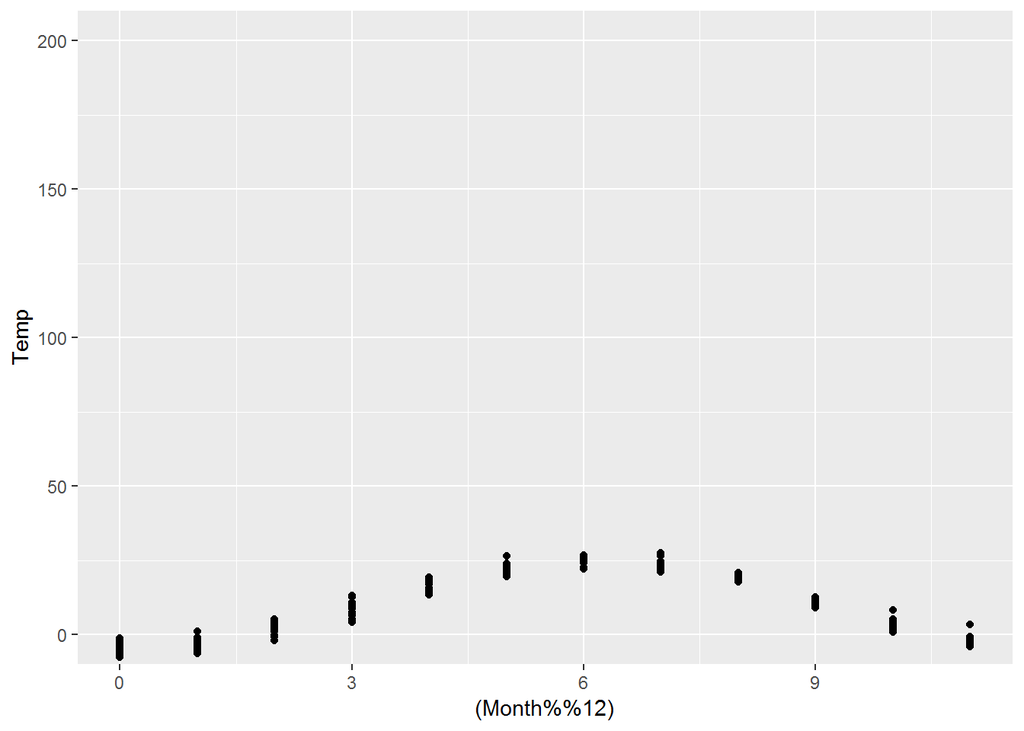

```r
ggplot(aes(x=(Month%%12),y=Temp), data=Mitchell)+
  geom_point() +
  coord_cartesian(ylim = c(0, 200))
```

Data Visualization Pioneers

1. John Tukey
2. William Playfair
3. William Playfair and the Psychology of Graphs

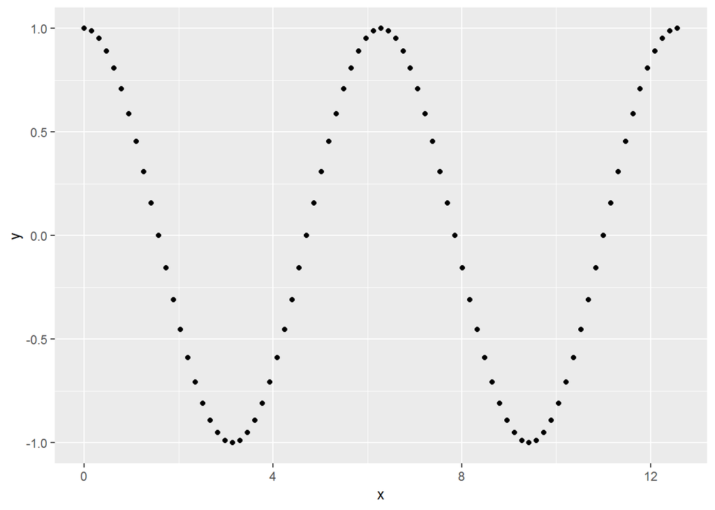

```r
x <- seq(0, 4*pi, pi/20)
y <- cos(x)
qplot(x = x, y = y)
```

```r
cor.test(x, y)
```

```
##
##  Pearson's product-moment correlation
##
## data:  x and y
## t = -8.3418e-16, df = 79, p-value = 1
## alternative hypothesis: true correlation is not equal to 0
## 95 percent confidence interval:
##  -0.2183494  0.2183494
## sample estimates:
##           cor
## -9.385288e-17
```

### Understanding Noise: Age to Age Months

Notes:

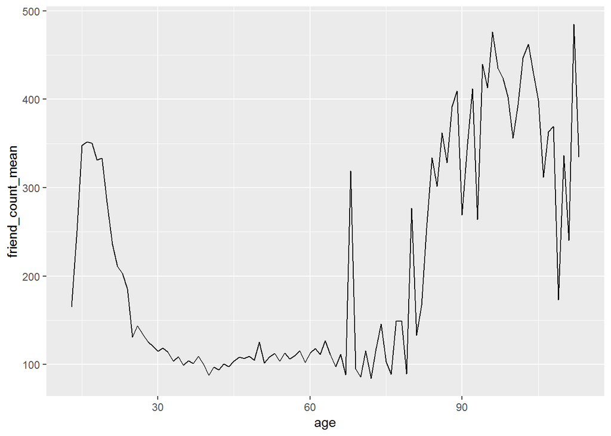

```r
ggplot(aes(x = age, y = friend_count_mean), data = pf.fc_by_age) +
  geom_line()
```

- The black line has a lot of random noise to it.
- The `mean_friend_count` rises and falls over each age.
- They are likely to be noise around the true smoother relationship between age and friend count. The estimated friend count for each age is the true mean plus some noise.
- We could estimate conditional means for each age, measured in months instead of years.
- Create a new variable that measures ages in months instead of years.
- Then plot a conditional mean for ages and months

```r
head(pf.fc_by_age)
```

```
## # A tibble: 6 x 4
##     age friend_count_mean friend_count_median     n
##   <int>             <dbl>               <dbl> <int>
## 1    13              165.                 74    484
## 2    14              251.                132   1925
## 3    15              348.                161   2618
## 4    16              352.                172.  3086
## 5    17              350.                156   3283
## 6    18              331.                162   5196
```

```r
pf.fc_by_age[17:19, ]
```

```
## # A tibble: 3 x 4
##     age friend_count_mean friend_count_median     n
##   <int>             <dbl>               <dbl> <int>
## 1    29              121.                66    1936
## 2    30              115.                67.5  1716
## 3    31              118.                63    1694
```

- As we can see, the `mean_friend_count` increases than decreases later.
- For 30 year old, the mean count is lower compared to the 29 year olds and the 31 year olds.

## Create an `age_with_months` variable

Assume the reference date for calculating age is December 31, 2013 and that the `age` variable gives age in years at the end of 2013.

The variable `age_with_months` in the data frame `pf` should be a decimal value. For example, the value of `age_with_months` for a 33 year old person born in March would be 33.75 since there are nine months from March to the end of the year. Similarly, someone who was 6 years and 6 months old would have an `age_with_months` value of 6.5.

```r
pf$age_with_months <-  pf$age + ( 12 - pf$dob_month) / 12
```

### Age with Months Means

- Smaller bin widths
- We’ll have more data points since age will be measured in months rather than in years.
- Get a new dataframe `pf.fc_age_months` with the average count and the median friend count for each age with months and the number of users in each group of age with months.
- Create a new data frame called `pf.fc_by_age_months` that contains the mean friend count, the median friend count, and the number of users in each group of age_with_months. The rows of the data framed should be arranged in increasing order by the `age_with_months` variable.
- For example, the first two rows of the resulting data frame would look something like…
- age_with_months friend_count_mean friend_count_median n

```r
# group data frame by age_with_months
age_with_months_groups <- group_by(pf, age_with_months)
# summarize age_with_months_group and create new data frame with
# median and mean friend_count, and the number of people in each group
pf.fc_by_age_months <- summarise(age_with_months_groups,
                              friend_count_mean = mean(friend_count),
                              friend_count_median = median(friend_count),
                              n = n())
# arrange it by age_with_months
pf.fc_by_age_months <- arrange(pf.fc_by_age_months, age_with_months)
head(pf.fc_by_age_months)
```

```
## # A tibble: 6 x 4
##   age_with_months friend_count_mean friend_count_median     n
##             <dbl>             <dbl>               <dbl> <int>
## 1            13.2              46.3                30.5     6
## 2            13.2             115.                 23.5    14
## 3            13.3             136.                 44      25
## 4            13.4             164.                 72      33
## 5            13.5             131.                 66      45
## 6            13.6             157.                 64      54
```

## Alternate Code By Chainning the Commands Together

```r
pf.fc_age_months <- pf %>%
  group_by(age_with_months) %>%
  summarise(friend_count_mean = mean(friend_count),
            friend_count_median = median(friend_count),
            n = n()) %>%
  arrange(age_with_months)

head(pf.fc_age_months)
```

```
## # A tibble: 6 x 4
##   age_with_months friend_count_mean friend_count_median     n
##             <dbl>             <dbl>               <dbl> <int>
## 1            13.2              46.3                30.5     6
## 2            13.2             115.                 23.5    14
## 3            13.3             136.                 44      25
## 4            13.4             164.                 72      33
## 5            13.5             131.                 66      45
## 6            13.6             157.                 64      54
```

### Noise in Conditional Means

- Make the plot of Mean Friend Count versus Age measured in months.
- Use a line to connect all the points.
- Subset the dataframe and investigate users with ages less then 71.
- This is a much noiier plot of `friend_count_mean` versus `age` in months

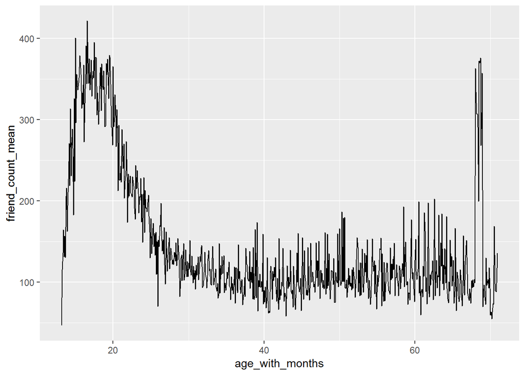

```r
ggplot(aes(x = age_with_months, y = friend_count_mean),
       data = subset(pf.fc_age_months, age_with_months < 71)) +
  geom_line()
```

### Smoothing Conditional Means

Notes:

Local Regression (LOESS) explained visually on the Simply Statistics blog.

The Details of [Loess and Lowess](https://en.wikipedia.org/wiki/Local_regression)

Differences in the two plots: - Let’s put the plots side by side so we can loock at them together.

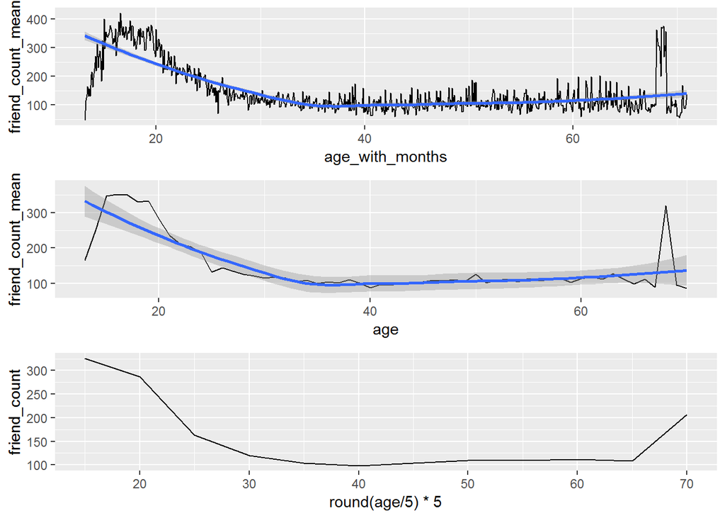

```r
p1 <- ggplot(aes(x = age, y = friend_count_mean),
       data = subset(pf.fc_by_age, age < 71)) +
  geom_line() +
  geom_smooth()

p2 <- ggplot(aes(x = age_with_months, y = friend_count_mean),
       data = subset(pf.fc_age_months, age_with_months < 71)) +
  geom_line() +
  geom_smooth()

p3 <- ggplot(aes(x = round(age / 5) *5, y = friend_count),
             data = subset(pf, age < 71)) +
  geom_line(stat = 'summary', fun.y = mean)

library(gridExtra)
grid.arrange(p2, p1, p3,  ncol = 1)
```

- By decreasing the size of our bins in `age` and increasing the number of bins in `age_with_months` we have less data to estimate each conditional mean.
- The noise is worse in the first plot since we have finer bin choices.
- Increasing the size of our bins in the second plot. We’ll cut our graph in pieces and average these mean friend counts together.
- P3 - estimate the mean more precisely but miss important features of the age.
- These three plots are an example of the Bias, Variance, Tradeoff and it’s similar to the tradeoff when choosing the bin width in histograms. Use a flexible statistical model to smooth our estimates of conditional means.
- Use `geom_smooth` to have a smooth modular function that will fit along the data.
- It doesn’t draw attention to the non-motonic relathionshio in the low ages. It misses the discontinuity at age 69. They are based on the idea that the true function is smooth but we know that there is some discontinuity in the relationship.

### Which Plot to Choose?

Notes:

- Create multiple visualizations and summaries of our data with different insights from each.
- Choose visualizations that best communicate the main findings of your work.

### Analyzing Two Variables

Reflection:

- Scatter plots;
- Conditional Means;
- Correlation Coefficients;